# Matrix Multiplication in Numpy / Bump Functions

```python
import numpy as np
```

```python
A = np.random.rand(3, 4) # 3 x 4 matrix
print(A)
```

```
[[0.09575228 0.55434985 0.90995206 0.06255401]
 [0.89781704 0.65408174 0.27265671 0.13155948]
 [0.00300291 0.46556105 0.92680705 0.00684176]]
```

```python
B = np.random.rand(4, 2)
print(B)
```

```
[[0.991572   0.1772219 ]
 [0.95702131 0.02050403]
 [0.02867298 0.1708966 ]
 [0.74110353 0.93729837]]
```

Define matrix multiplication of an $M \times K$ matrix $A$ by a $K \times N$ matrix $B$ as the product $AB$, which is an $M \times N$ matrix, where

$AB[i, j] = A[i, :] \cdot B[:, j]$

The element $AB_{ij}$ is the dot product of the $i^{th}$ row of $A$ and the $j^{th}$ column of $B$

Below are a couple of examples

### Example1

A $5 \times 3$ matrix multiplied by a $3 \times 4$ matrix yields a $5 \times 4$ matrix. For example, row 3, column 4 can be obtained as follows:

[figure not shown]

Here's an animation showing how to obtain the rest of the rows and columns ([Click here](https://www.youtube.com/watch?v=7bs_BGrO3BQ) to watch a youtube video where you can pause the frames if needed)

[figure not shown]

### Example2

A $2 \times 4$ matrix multiplied by a $4 \times 3$ matrix yields a $2 \times 3$ matrix ([Click here](https://www.youtube.com/watch?v=-MnxPjXprpM) to watch a version of this video on youtube where you can pause the frames if needed)

[figure not shown]

```python
def matrixmul(A, B):
    M = A.shape[0]
    K = A.shape[1]
    assert(B.shape[0] == K)
    N = B.shape[1]
    AB = np.zeros((M, N))
    for i in range(M):
        for j in range(N):
            AB[i, j] = np.sum(A[i, :]*B[:, j])
    return AB
```

```python
AB = matrixmul(A, B)
print(AB)
```

```
[[0.69791993 0.24247529]
 [1.62153748 0.34243074]
 [0.48017422 0.17487901]]
```

```python
AB2 = np.dot(A, B)
print(AB2)
```

```
[[0.69791993 0.24247529]
 [1.62153748 0.34243074]
 [0.48017422 0.17487901]]
```

A spectrogram can be thought of as a matrix! This point of view will be very powerful, and it will help us to implement a variety of algorithms efficiently. The example below is a $2049 \times 431$ matrix, which means it has 2049 non-redundant frequency bins and 431 windows in time.

```python
import numpy as np
import matplotlib.pyplot as plt
import IPython.display as ipd
import librosa
import librosa.display
x, sr = librosa.load("beatles.wav")
hop_length=512
win = 4096
S = librosa.stft(x, hop_length=hop_length, n_fft=win)
S = np.abs(S)
Sdb = librosa.amplitude_to_db(S,ref=np.max)
```

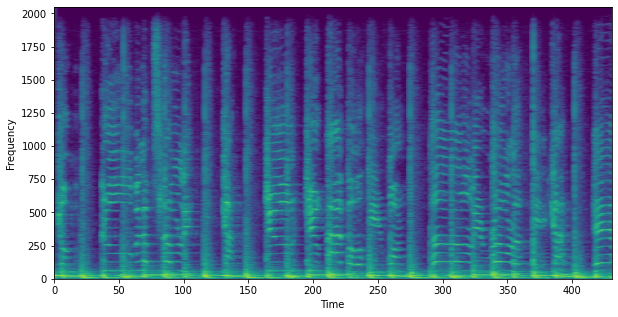

```python
plt.figure(figsize=(10, 5))
plt.imshow(Sdb, aspect='auto')#, extent=(0, hop_length*S.shape[1]/sr, sr/2, 0))
plt.gca().invert_yaxis()
plt.xlabel("Time")
plt.ylabel("Frequency ")
```

```python
print(Sdb.shape)
```

```
(2049, 431)
```

## Bump functions

Let's say we want to extract just a small frequency region of the spectrogram. We can take the dot product of a column of a spectrogram with something called a "bump function," which peaks around the frequency bin of interest and falls to zero quickly on either end

### $b_{c, \sigma}(x) = e^{-(x-c)^2/\sigma^2}$

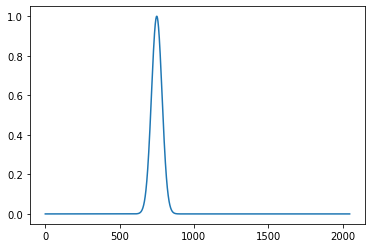

```python
c = 750
sigma = 50
b = np.exp(-(np.arange(Sdb.shape[0])-c)**2/sigma**2)
plt.plot(b)
```

We can certainly manually apply the bump function to each column with a loop

[figure not shown]

```python
y = np.zeros(Sdb.shape[1])
for j in range(Sdb.shape[1]):
    y[j] = np.sum(Sdb[:, j]*bump)
plt.plot(y)
```

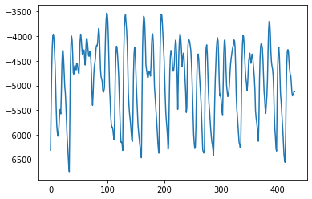

```python
c = 750
sigma = 50
Bump = np.zeros((1, Sdb.shape[0]))
Bump[0, :] = np.exp(-(np.arange(Sdb.shape[0])-c)**2/sigma**2)
y = np.dot(Bump, Sdb).flatten()
plt.plot(y)
```